# Monthly HCV cohort report

# Report details

Reporting date range: **01 Jan 2009 - 31 Dec 2009**  
Date and time report generated: **17 December 2020, 21:29 UTC**  
Reporting package versions:  
**genericreportr**: 0.0.1.1  
**idreportr**: 0.0.3.9001

Comments or questions to: **his@oca.msf.org**

| Programme summary | Figure |
| --- | --- |
| First treatment episode start date | 17 Nov 2008 |
| Number of treatment initiations | 875 |

Data for **01 Jan 2009 - 31 Dec 2009:**

| Reporting period summary | Figure |
| --- | --- |
| Number of treatment episodes started | 702 |
| Number of treatment outcomes registered | 500 |

# Cohort inclusions

## HCV treatment initiations

### Table

|  | Previous 13 months up to 31 December 2009 N (%) | Previous 13 months up to 31 December 2009 Total |
| --- | --- | --- |
| Month: |  | 815 |
| Dec-09 | 249 (30.6%) |  |
| Nov-09 | 28 (3.4%) |  |
| Oct-09 | 26 (3.2%) |  |
| Sep-09 | 29 (3.6%) |  |
| Aug-09 | 28 (3.4%) |  |
| Jul-09 | 15 (1.8%) |  |
| Jun-09 | 18 (2.2%) |  |
| May-09 | 40 (4.9%) |  |
| Apr-09 | 29 (3.6%) |  |
| Mar-09 | 19 (2.3%) |  |
| Feb-09 | 71 (8.7%) |  |
| Jan-09 | 150 (18.4%) |  |
| Dec-08 | 113 (13.9%) |  |

|  | Full programme inclusion up to 31 December 2009 N (%) | Full programme inclusion up to 31 December 2009 Total |
| --- | --- | --- |
| Month: |  | 875 |
| Dec | 362 (41.4%) |  |
| Nov | 88 (10.1%) |  |
| Oct | 26 (3.0%) |  |
| Sep | 29 (3.3%) |  |
| Aug | 28 (3.2%) |  |
| Jul | 15 (1.7%) |  |
| Jun | 18 (2.1%) |  |
| May | 40 (4.6%) |  |
| Apr | 29 (3.3%) |  |
| Mar | 19 (2.2%) |  |
| Feb | 71 (8.1%) |  |
| Jan | 150 (17.1%) |  |

### Monthly initiations

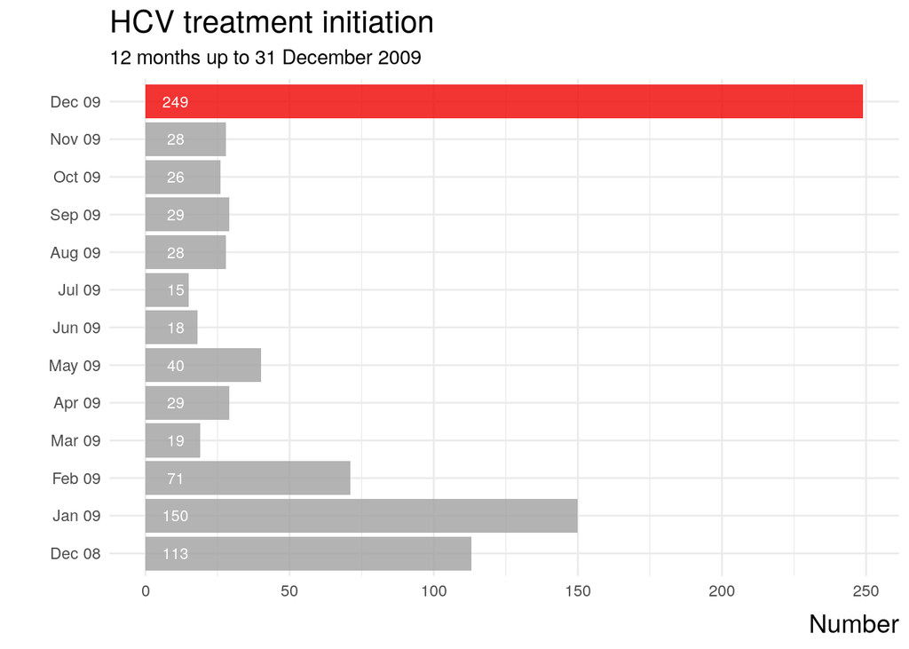

### Quarterly initiations

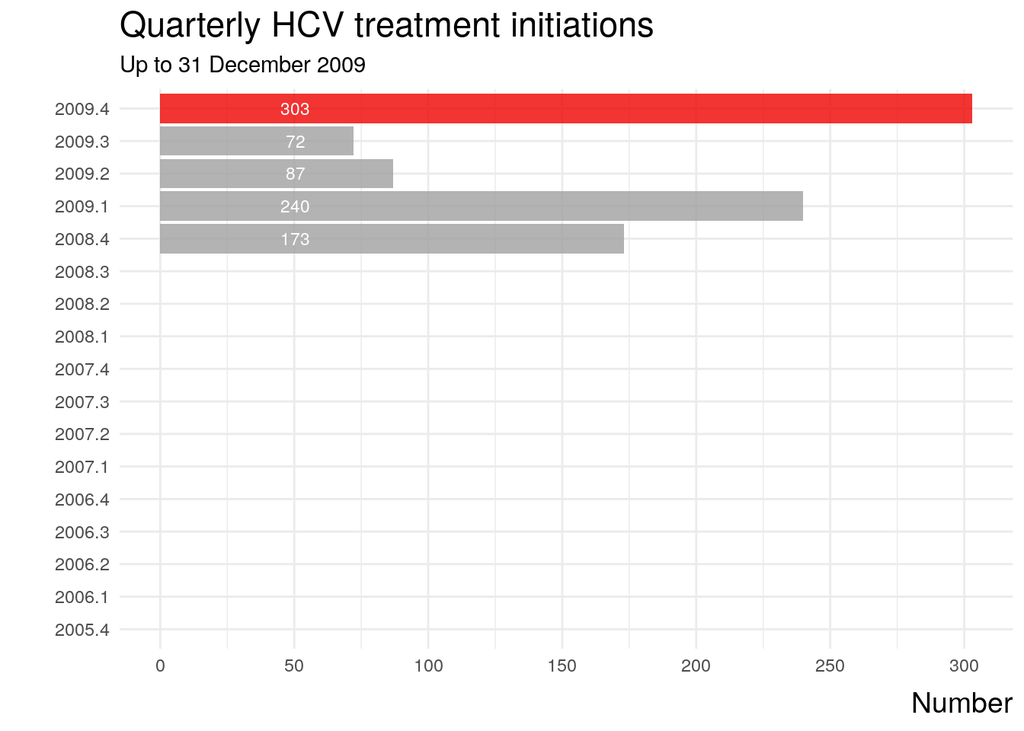

### Definitions

The information in this section aims to summarise programme entry over time. This may be presented by treatment initiation or first consultation. Counts are split into calendar months or quarters and are tabulated and graphically represented. For comparison with more recent information, tables summarising monthly inclusions over the life of a programme are included.

Definition

**Table**  
Summarises the number and percentage of patients included in the cohort by calendar month. Episodes (e.g. treatment initation or pregnancy), rather than individual patients, are counted in this table.

**Monthly & Quarterly plots**  
Monthly and quarterly bar plots visually display programme entry by time period. These counts may be segregated further in some reports (e.g. TB treatment type). This type of plot should quickly illustrate seasonal or temporal changes in programme inclusion

**Key variables**

> Cohort inclusion: Treatment start date

**Key data form**

> Form 2 Treatment Initiation_Début traitement

## Registration characteristics

### Age, gender and BMI

|  | Reporting period N (%) | Reporting period Total | Previous 12 months N (%) | Previous 12 months Total | Full programme N (%) | Full programme Total |
| --- | --- | --- | --- | --- | --- | --- |
| Age: |  | 702 |  | 707 |  | 875 |
| < 15y | 99 (14.1%) |  | 99 (14.0%) |  | 126 (14.4%) |  |
| 15-44y | 196 (27.9%) |  | 199 (28.1%) |  | 248 (28.3%) |  |
| ≥ 45y | 407 (58.0%) |  | 409 (57.9%) |  | 501 (57.3%) |  |
| 'Missing' | 0 (0.0%) |  | 0 (0.0%) |  | 0 (0.0%) |  |
| Gender: |  | 702 |  | 707 |  | 875 |
| Female | 330 (47.0%) |  | 331 (46.8%) |  | 408 (46.6%) |  |
| Male | 360 (51.3%) |  | 364 (51.5%) |  | 450 (51.4%) |  |
| Unknown | 7 (1.0%) |  | 7 (1.0%) |  | 10 (1.1%) |  |
| 'Missing' | 5 (0.7%) |  | 5 (0.7%) |  | 7 (0.8%) |  |
| BMI: |  | 702 |  | 707 |  | 875 |
| ≥ 18.5 | 488 (69.5%) |  | 493 (69.7%) |  | 603 (68.9%) |  |
| < 18.5 | 214 (30.5%) |  | 214 (30.3%) |  | 272 (31.1%) |  |
| 'Missing' | 0 (0.0%) |  | 0 (0.0%) |  | 0 (0.0%) |  |

### HCV genotype and Fibrosis score

|  | Reporting period N (%) | Reporting period Total | Previous 12 months N (%) | Previous 12 months Total | Full programme N (%) | Full programme Total |
| --- | --- | --- | --- | --- | --- | --- |
| HCV genotype: |  | 702 |  | 707 |  | 875 |
| Genotype 1 | 0 (0.0%) |  | 0 (0.0%) |  | 0 (0.0%) |  |
| Genotype 1a | 354 (50.4%) |  | 357 (50.5%) |  | 454 (51.9%) |  |
| Genotype 1b | 49 (7.0%) |  | 49 (6.9%) |  | 55 (6.3%) |  |
| Genotype 2 | 0 (0.0%) |  | 0 (0.0%) |  | 0 (0.0%) |  |
| Genytype 3 | 0 (0.0%) |  | 0 (0.0%) |  | 0 (0.0%) |  |
| Genotype 4 | 0 (0.0%) |  | 0 (0.0%) |  | 0 (0.0%) |  |
| Other | 0 (0.0%) |  | 0 (0.0%) |  | 0 (0.0%) |  |
| 'Missing' | 299 (42.6%) |  | 301 (42.6%) |  | 366 (41.8%) |  |
| Fibrosis score: |  | 702 |  | 707 |  | 875 |
| F0 no fibrosis | 125 (17.8%) |  | 125 (17.7%) |  | 145 (16.6%) |  |
| F1 mild fibrosis | 133 (18.9%) |  | 134 (19.0%) |  | 172 (19.7%) |  |
| F2 moderate fibrosis | 114 (16.2%) |  | 116 (16.4%) |  | 142 (16.2%) |  |
| F3 severe fibrosis | 132 (18.8%) |  | 132 (18.7%) |  | 159 (18.2%) |  |
| F4 cirrhosis | 126 (17.9%) |  | 128 (18.1%) |  | 166 (19.0%) |  |
| Not specified | 51 (7.3%) |  | 51 (7.2%) |  | 65 (7.4%) |  |
| 'Missing' | 21 (3.0%) |  | 21 (3.0%) |  | 26 (3.0%) |  |

### Definitions

This section includes information recorded from patients when they enter the cohort. Relevant variables are presented for each disease. Three reporting periods have been included - the reporting period defined by the user, the 12 months prior to the end of the user-defined reporting period, and the full programme duration.

**Key data forms**

> New patient registration form  
> 1 History HCV_ Antécédents HCV

# Treatment monitoring

## Regimen at initiation

### Table

|  | Reporting period N (%) | Reporting period Total | Previous 12 months N (%) | Previous 12 months Total | Full programme N (%) | Full programme Total |
| --- | --- | --- | --- | --- | --- | --- |
| Regimen: |  | 702 |  | 707 |  | 875 |
| SOF/DCV | 333 (47.4%) |  | 337 (47.7%) |  | 421 (48.1%) |  |
| SOF/DCV/RBV | 0 (0.0%) |  | 0 (0.0%) |  | 0 (0.0%) |  |
| SOF/VEL/VOX | 32 (4.6%) |  | 32 (4.5%) |  | 41 (4.7%) |  |
| Other | 87 (12.4%) |  | 87 (12.3%) |  | 104 (11.9%) |  |
| 'Missing' | 250 (35.6%) |  | 251 (35.5%) |  | 309 (35.3%) |  |

### Definitions

This section provides a summary of the treatment regimens prescribed to at initiation to those starting treatment during the defined period.

Definition

**Regimens**  
A selection of the most frequently chosen regimens has been tabulated. Three reporting periods have been included - the reporting period defined by the user, the 12 months prior to the end of the user-defined reporting period, and the full programme duration.

**Key data forms**

> Form 4 Clin Assess Treat HCV_Éval Clin Trait HCV

# Cohort outcome reporting

## Outcomes by quarter

|  | Q4, 2008 N (%) | Q4, 2008 N |
| --- | --- | --- |
| Outcome: |  | 173 |
| Cured | 147 (85.0%) |  |
| Completed, post treatment VL not done | 7 (4.0%) |  |
| Died | 2 (1.2%) |  |
| Failed | 3 (1.7%) |  |
| LTFU during treatment | 7 (4.0%) |  |
| Other | 7 (4.0%) |  |
| 'Missing' | 0 (0.0%) |  |

## Current quarter outcome plot

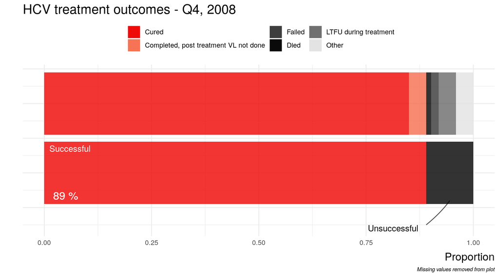

## Quarterly outcomes plot

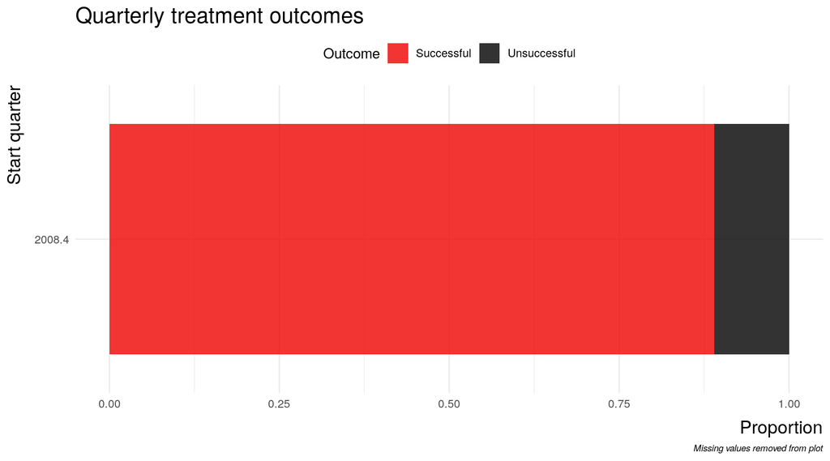

## Definitions

This section summarises the end of treatment outcomes through using cohort reporting principles. Treatment cohorts are, by convention, defined by the period of treatment initiation. Treatment initation is included here either as a quarter or semester depending on the disease and treatment type

Definition

**Episode**  
The counts included in this table represent treatment episodes rather than individual patients. Therefore, patients who started treatment more than once during the defined period will be counted multiple times.

**Loss to Follow-up**  
Loss to follow up in this table is based on outcomes recorded during data entry. It has not been calculated through patient attendance records.

**HCV treatment cohort**  
The treatment cohort is defined by episodes started greater than 12 months prior to reporting such that all outcomes should be available.

**Key data form**

> Form 6 Treatment Outcome HCV _ Issue du traitement HCV